# Course Project 1

## Loading and preprocessing the data

```r
data=read.csv("activity.csv")
head(data)
```

```
##   steps       date interval
## 1    NA 2012-10-01        0
## 2    NA 2012-10-01        5
## 3    NA 2012-10-01       10
## 4    NA 2012-10-01       15
## 5    NA 2012-10-01       20
## 6    NA 2012-10-01       25
```

## What is mean total number of steps taken per day?

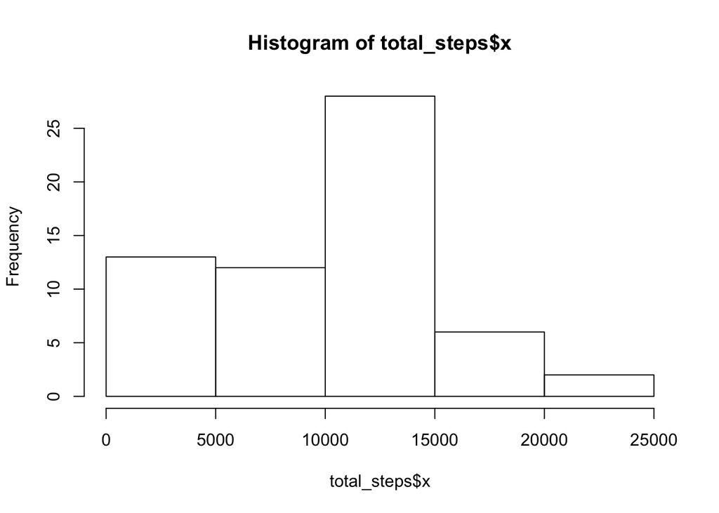

```r
total_steps <- aggregate(data$steps,list(data$date), sum, na.rm=TRUE)
hist(total_steps$x)
```

```r
mean_steps <- mean(total_steps$x)
mean_steps
```

```
## [1] 9354.23
```

```r
median_steps <- median(total_steps$x)
head(median_steps)
```

```
## [1] 10395
```

## What is the average daily activity pattern?

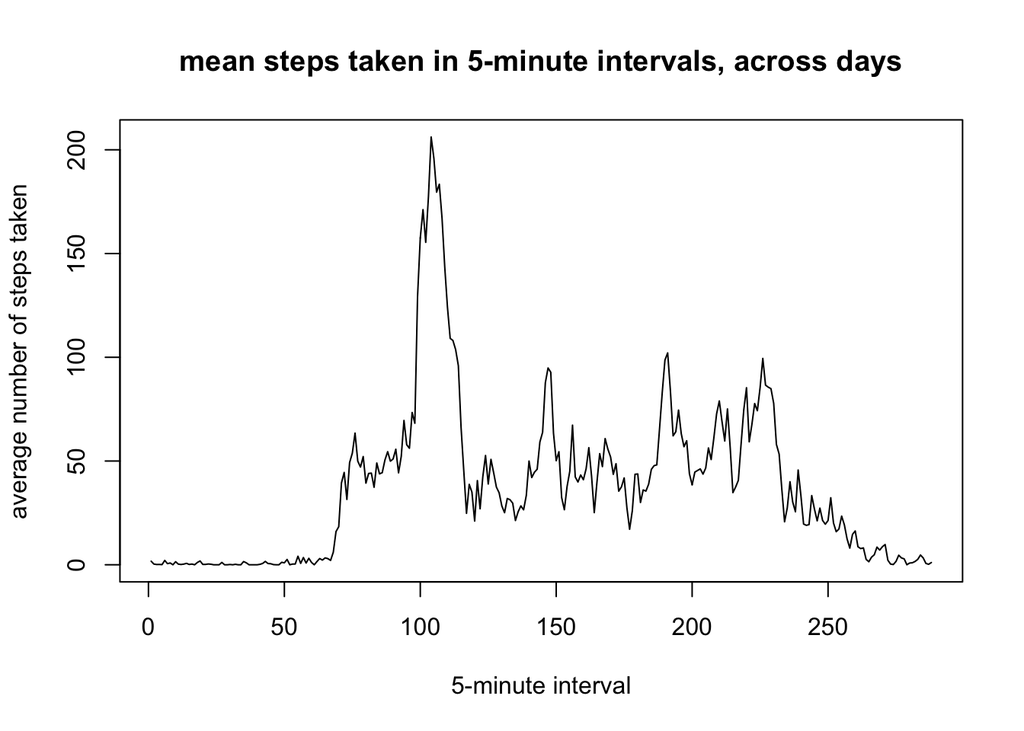

```r
average_steps_intervals <- tapply(data$steps, data$interval, FUN=mean, na.rm=TRUE)
plot(average_steps_intervals,type="l", xlab="5-minute interval", ylab="average number of steps taken", main = "mean steps taken in 5-minute intervals, across days")
```

### Which 5-minute interval, on average across all the days in the dataset, contains the maximum number of steps?

```r
names(which.max(average_steps_intervals))
```

```
## [1] "835"
```

## Imputing missing values

### Calculate and report the total number of missing values in the dataset (i.e. the total number of rows with 𝙽𝙰s)

```r
length(which(is.na(data)))
```

```
## [1] 2304
```

### Devise a strategy for filling in all of the missing values in the dataset.

We plan to fill in the values based on the average values we have computed for ‘average_steps_intervals’ above:

```r
non_na_data <- data
for (x in 1:nrow(non_na_data)) {
  if (is.na(non_na_data$steps[x])) {
    non_na_data$steps[x] <- average_steps_intervals[as.character(non_na_data[x,3])]
  }
}
head(non_na_data)
```

```
##       steps       date interval
## 1 1.7169811 2012-10-01        0
## 2 0.3396226 2012-10-01        5
## 3 0.1320755 2012-10-01       10
## 4 0.1509434 2012-10-01       15
## 5 0.0754717 2012-10-01       20
## 6 2.0943396 2012-10-01       25
```

### checking if there are any NA values in the new dataset

```r
length(which(is.na(non_na_data)))
```

```
## [1] 0
```

### Histogram of the new data, along with new and old mean

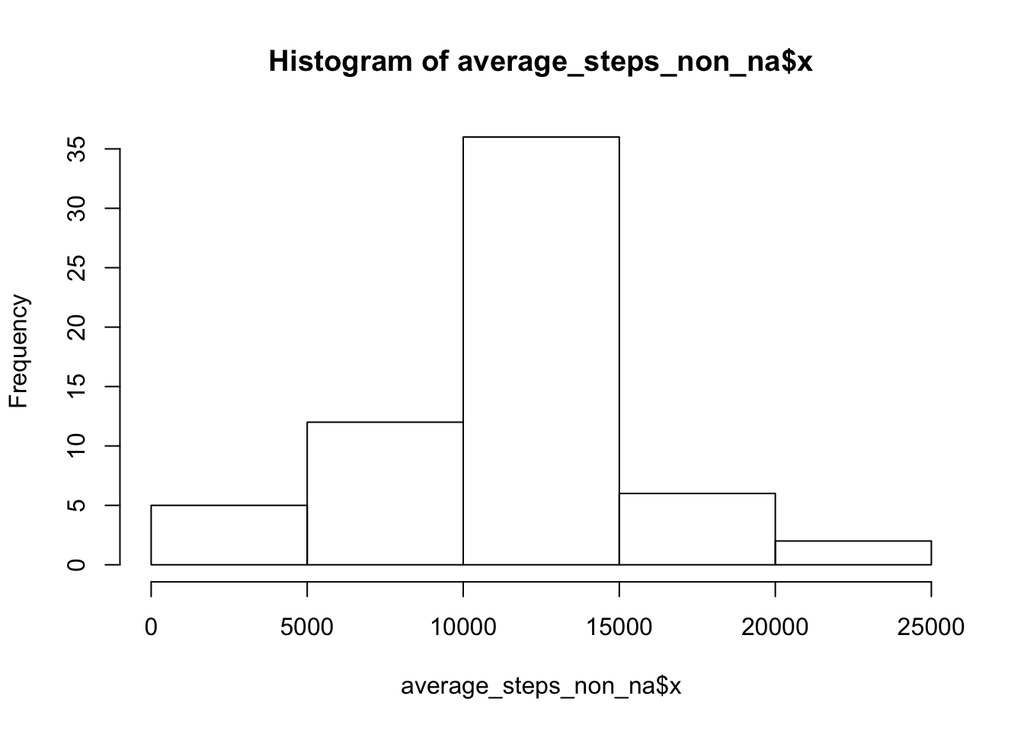

```r
average_steps_non_na <- aggregate(non_na_data$steps,list(non_na_data$date), sum)
hist(average_steps_non_na$x)
```

```r
new_mean <- mean(average_steps_non_na$x)
new_mean
```

```
## [1] 10766.19
```

```r
new_median <- median(average_steps_non_na$x)
new_median
```

```
## [1] 10766.19
```

```r
old_mean <-mean(total_steps$x)
old_mean
```

```
## [1] 9354.23
```

```r
new_mean-old_mean
```

```
## [1] 1411.959
```

```r
old_median <-median(total_steps$x)
old_median
```

```
## [1] 10395
```

```r
new_median - old_median
```

```
## [1] 371.1887
```

The new mean and median are different from previous. Also new mean and the median are the same now

## Are there differences in activity patterns between weekdays and weekends?

### Create a new factor variable in the dataset with two levels – “weekday” and “weekend” indicating whether a given date is a weekday or weekend day.

```r
weekday = c("Monday", "Tuesday", "Wednesday", "Thursday", "Friday")
weekend = c('Saturday', 'Sunday')
non_na_data$is_weekday <- weekdays(as.Date(non_na_data$date))
for (x in 1:nrow(non_na_data)) {
  if (non_na_data$is_weekday[x] %in% weekday){
    non_na_data$is_weekday[x] <- 1
  }
  else if (non_na_data$is_weekday[x] %in% weekend){
    non_na_data$is_weekday[x] <- 0
  }
}
head(non_na_data)
```

```
##       steps       date interval is_weekday
## 1 1.7169811 2012-10-01        0          1
## 2 0.3396226 2012-10-01        5          1
## 3 0.1320755 2012-10-01       10          1
## 4 0.1509434 2012-10-01       15          1
## 5 0.0754717 2012-10-01       20          1
## 6 2.0943396 2012-10-01       25          1
```

### Make a panel plot containing a time series plot (i.e. 𝚝𝚢𝚙𝚎 = “𝚕”) of the 5-minute interval (x-axis) and the average number of steps taken, averaged across all weekday days or weekend days (y-axis). See the README file in the GitHub repository to see an example of what this plot should look like using simulated data.

[figure not shown]

```r
average_steps_weekdays <- aggregate(non_na_data$steps, by=list(non_na_data$interval,non_na_data$is_weekday) , FUN=mean)
names(average_steps_weekdays) <- c('Intervals','weekdays', 'avg_steps')
library(lattice)
xyplot(avg_steps ~ Intervals | weekdays, average_steps_weekdays, type='l', layout=c(1,2), xlab='Number of Steps', ylab = 'Interval', main='0 for weekend, 1 for weekday')
```